# Analysis of Variance Homework

Testing, dissecting, and reporting differences among group means

Author

YOUR NAME HERE

## The Idea

An analysis of variance answers a deliberately narrow question: is *at least one* group mean different from the others? A reproducible ANOVA does three more things before it says anything about the science, and it reports every one of them:[^1]

1. **Test the overall hypothesis once.** Fit a single model with `aov()` rather than a pile of pairwise $t$-tests, so the chance of a false positive stays at $\alpha$, and report its $F$ statistic, both degrees of freedom, and $P$-value.
2. **Say how much it matters and where.** Report how much of the variation the groups explain ($R^2$), then use a *post hoc* test (`TukeyHSD()`) to find which groups actually differ, and by how much, in the units of the response.
3. **Ask whether a second factor changes the answer.** Add the second factor and its interaction, and look at the mean of every combination of the two before interpreting the interaction term.

The write-up then reports each step, with every number read from a variable in memory using an inline `` `r ` `` expression, never typed by hand.

The worked example below uses the Rice Rivers Center data you know from the Tidyverse, Correlation, and Regression modules to show the whole workflow on dissolved oxygen. Your assignment applies the same structure to a different response from the same buoy: the depth of the river.

**NoteWriting like a research paper**

As in the Regression homework, the documents you turn in should read like research, not like R. Your header now includes `echo: false` (see The full YAML header), which hides the code chunks in the rendered page. The code still has to be there and still has to produce every number, table, and figure, and I can see all of it through the “</> Code” button, but the reader sees only the science. The worked example below shows its code so you can see how it is built; your rendered document will not.

## A Worked Example

### Methods

You can use this chunk exactly as it is in your own document. The daily averaging is the same as in the Regression homework; `month( Date, label = TRUE )` comes from the Tidyverse module and `droplevels()` (which removes the nine months with no data) from the Factors module.

```r
library( tidyverse )
library( lubridate )
library( knitr )
library( kableExtra )

url <- "https://dyerlabteaching.github.io/CourseData/Environmental/RiceRivers_2014.csv"

read_csv( url ) |>
  mutate( Date =  mdy_hms( DateTime, tz = "EST" ) )  |>
  group_by( Date ) |>
  summarize( Rain = sum( Rain_in, na.rm = TRUE ),
             WaterTemp = mean( H2O_TempC, na.rm = TRUE ),
             DO = mean( ODO_mgl, na.rm = TRUE ),
             Depth = mean( Depth_m, na.rm = TRUE ) ) |>
  mutate( Month = droplevels( month( Date, label = TRUE ) ),
          Weather = factor( ifelse( Rain > 0, "Rain", "Dry" ) ) ) -> rice

summary( rice )
```

```
      Date                          Rain             WaterTemp
 Min.   :2014-01-01 00:00:00   Min.   :0.0000000   Min.   :-0.140
 1st Qu.:2014-01-22 08:22:30   1st Qu.:0.0000000   1st Qu.: 3.930
 Median :2014-02-12 16:45:00   Median :0.0000000   Median : 5.450
 Mean   :2014-02-12 16:45:00   Mean   :0.0008412   Mean   : 5.529
 3rd Qu.:2014-03-06 01:07:30   3rd Qu.:0.0000000   3rd Qu.: 7.410
 Max.   :2014-03-27 09:30:00   Max.   :0.3470000   Max.   :13.300
                                                   NA's   :1
       DO            Depth       Month      Weather
 Min.   :10.34   Min.   :3.705   Jan:2976   Dry :7757
 1st Qu.:12.34   1st Qu.:4.451   Feb:2688   Rain: 442
 Median :12.88   Median :4.684   Mar:2535
 Mean   :12.88   Mean   :4.677
 3rd Qu.:13.34   3rd Qu.:4.913
 Max.   :14.99   Max.   :5.454
 NA's   :1
```

> **Exploration.** Cold water holds more dissolved oxygen (DO) than warm water, so we expected DO to fall as the river warmed through the winter. We plotted daily mean DO for each month, marking rainy and dry days.

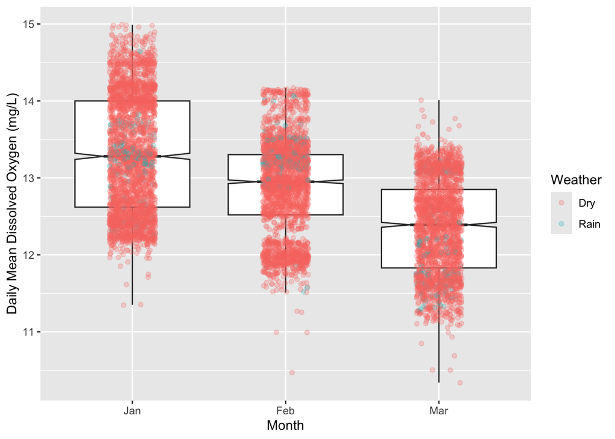

```r
ggplot( rice, aes(x = Month, y = DO) ) +
  geom_boxplot( outlier.shape = NA, notch=TRUE ) +
  geom_jitter( aes(color = Weather), width = 0.15, alpha = 0.25 ) +
  ylab( "Daily Mean Dissolved Oxygen (mg/L)" )
```

> **One-factor model.** We tested the null hypothesis that mean DO was the same in all three months ($H_O: \mu_{Jan} = \mu_{Feb} = \mu_{Mar}$) with a one-way analysis of variance, and calculated the fraction of the variation explained by month as $R^2 = SS_{Month} / SS_{Total}$ from the ANOVA table.

```r
fit_month <- aov( DO ~ Month, data = rice )
tab_month <- anova( fit_month )
tab_month
```

```
Analysis of Variance Table

Response: DO
            Df Sum Sq Mean Sq F value    Pr(>F)
Month        2 1257.8  628.91  1428.2 < 2.2e-16 ***
Residuals 8195 3608.8    0.44
---
Signif. codes:  0 '***' 0.001 '**' 0.01 '*' 0.05 '.' 0.1 ' ' 1
```

> **Post hoc comparisons.** To find which months differed, we compared all pairs of months with Tukey’s Honest Significant Differences.

```r
tuk_month <- TukeyHSD( fit_month )
tuk_month
```

```
  Tukey multiple comparisons of means
    95% family-wise confidence level

Fit: aov(formula = DO ~ Month, data = rice)

$Month
              diff        lwr        upr p adj
Feb-Jan -0.4333449 -0.4747405 -0.3919492     0
Mar-Jan -0.9585957 -1.0006425 -0.9165488     0
Mar-Feb -0.5252508 -0.5683179 -0.4821836     0
```

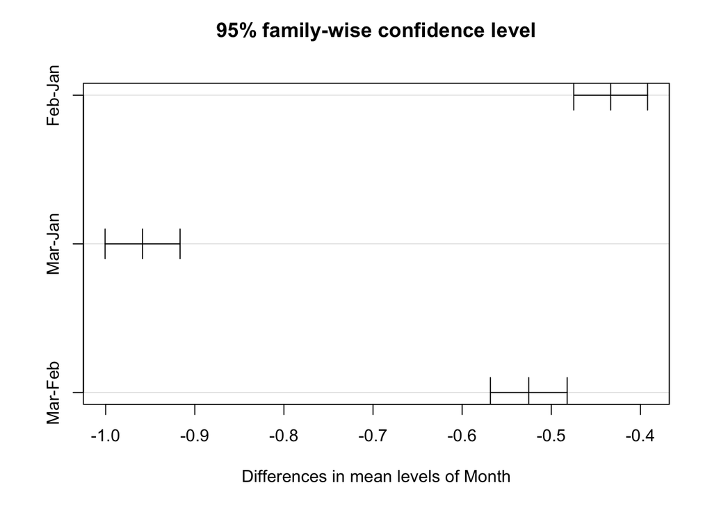

```r
plot( tuk_month )
```

> **Two-factor model.** To ask whether rain changed DO, and whether its effect depended upon the month, we fit a two-factor model with month, weather, and their interaction. We summarized the mean DO and number of days in every month-by-weather combination and plotted those means with one line per weather type.

```r
fit_both <- aov( DO ~ Month * Weather, data = rice )
tab_both <- anova( fit_both )
tab_both
```

```
Analysis of Variance Table

Response: DO
                Df Sum Sq Mean Sq   F value    Pr(>F)
Month            2 1257.8  628.91 1439.2111 < 2.2e-16 ***
Weather          1    0.2    0.23    0.5233    0.4694
Month:Weather    2   28.8   14.41   32.9723 5.466e-15 ***
Residuals     8192 3579.8    0.44
---
Signif. codes:  0 '***' 0.001 '**' 0.01 '*' 0.05 '.' 0.1 ' ' 1
```

The table of cell means is built in the chunk below the sentence that introduces it, and given a label and caption so the Results can cite it as Table 1.[^2]

```r
rice |>
  group_by( Month, Weather ) |>
  summarize( DO = mean( DO ), Days = n() ) -> do_means

do_means |>
  kable( digits = 2 ) |>
  kable_paper( "striped", full_width = FALSE )
```

Table 1: Mean daily dissolved oxygen (mg/L) and number of days for each month and weather type at the Rice Rivers Center, January to March 2014.

| Month | Weather | DO | Days |
| --- | --- | --- | --- |
| Jan | Dry | NaN | 2840 |
| Jan | Rain | 13.12 | 136 |
| Feb | Dry | 12.86 | 2543 |
| Feb | Rain | 13.22 | 145 |
| Mar | Dry | 12.37 | 2374 |
| Mar | Rain | 12.16 | 161 |

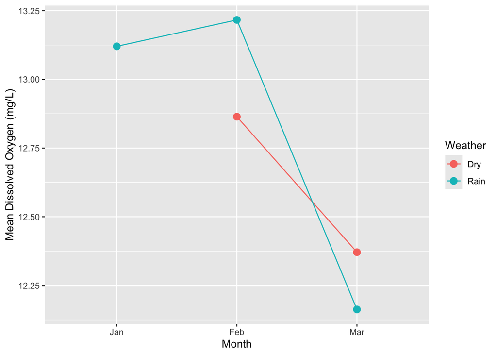

```r
ggplot( do_means, aes(x = Month, y = DO, color = Weather, group = Weather) ) +
  geom_point( size = 3 ) +
  geom_line() +
  ylab( "Mean Dissolved Oxygen (mg/L)" )
```

### Preparing the reporting values

Before writing the Results, pull the numbers you will quote into one chunk, `format()` them, and give each a short name. `TukeyHSD()` returns a list with one matrix per factor; rows are the pairs of groups (e.g. `"Mar-Jan"`) and columns are `diff`, `lwr`, `upr`, and `p adj`. The ANOVA tables can be indexed by row name and column name the same way.

```r
N <- nrow( rice )
n_rain <- sum( rice$Weather == "Rain" )
F_month <- format( tab_month["Month", "F value"], digits = 3 )
df1_month <- tab_month["Month", "Df"]
df2_month <- tab_month["Residuals", "Df"]
P_month <- format( tab_month["Month", "Pr(>F)"], digits = 3 )
R2_month <- format( tab_month["Month", "Sum Sq"] / sum( tab_month$`Sum Sq` ), digits = 2 )
P_tukey_max <- format( max( tuk_month$Month[, "p adj"] ), digits = 2 )
drop_JanMar <- format( -tuk_month$Month["Mar-Jan", "diff"], digits = 2 )
P_weather <- format( tab_both["Weather", "Pr(>F)"], digits = 2 )
P_inter <- format( tab_both["Month:Weather", "Pr(>F)"], digits = 2 )
```

### Results

[output not shown]

## Your Assignment

The James River at the Rice Rivers Center is tidal, so its depth rises and falls twice a day, but the daily mean should track how much water is coming down the river. Rain upstream should raise it, and so might the seasons.

Produce a standalone **Methods** and **Results** write-up asking **whether the daily mean depth of the river (`Depth`, in meters) differs among months, and whether rainy days differ from dry days**. Use the data chunk from the worked example as it is; it already includes `Depth`.

Then answer briefly, a sentence or two each:

- Suppose you had skipped the ANOVA and compared each pair of months with its own `t.test()` at $\alpha = 0.05$. What is the chance of at least one false positive across those comparisons if the months really were all the same, and how does `TukeyHSD()` avoid that problem?
- We averaged the 15-minute readings into one value per day. If you instead ran your one-factor model on all 8,199 raw readings, what would happen to the residual degrees of freedom and the *P*-value, and which assumption of the analysis of variance would that violate? Are consecutive *days* fully independent of each other either?

## What You Turn In

**One file: the rendered, self-contained `.html`.** Not the `.qmd`, and not a copy of this page. Make a *new* Quarto document that contains only your own work: your Methods and Results sections with their chunks, the reporting-values chunk, and your brief answers to the two questions.

The worked example above is a model to imitate, not text to paste into your document.

### Making the document

1. In RStudio: **File ▸ New File ▸ Quarto Document…**
2. In the dialog, enter a title and your name, leave the engine set to **Knitr**, and click **Create**.
3. Delete everything RStudio puts below the header (the “Quarto” boilerplate and its example chunk).
4. Replace the header it generated with the one below.
5. Save the file into your course project folder as `Analysis-of-Variance-Homework.qmd`.
6. Write your content, then click **Render** to produce the `.html`. That HTML file is what you submit.

### The full YAML header

```yaml
---
title: "Analysis of Variance Homework"
author: "Your Name"
date: today
abstract: |
  A sentence or two saying what the document does: the data, the question, and what you found.
format:
  html:
    self-contained: true
    code-tools: true
execute:
  echo: false
---
```

- **`title` / `author` / `date` / `abstract`**: complete front matter, including a short summary where a scientific paper would put its abstract. `date: today` fills itself in at render time.
- **`format: html`**: render to a single web page I can open in any browser.
- **`self-contained: true`**: bundle every image, style, and script *into* that one `.html` file. Without it the file depends on a sibling `*_files/` folder that never makes it into the upload, and your figures and formatting arrive broken.
- **`code-tools: true`**: adds the “</> Code” button in the top-right that lets a reader view the full source. **This is not optional.** If I cannot see the code behind a wrong answer, I cannot tell whether you were one typo away or lost the plot entirely. That means I cannot give partial credit, point out where it went sideways, or help you fix it. A rendered page with no visible code is graded only on what rendered.
- **`execute: echo: false`**: It hides every code chunk in the rendered page, so the reader sees only your words, tables, figures, and inline values, the way a published paper reads. The code still runs, and it is still in the document: the “</> Code” button from `code-tools: true` shows the full source to anyone who wants it. Write your Methods so they make sense to someone who never opens that button.

Use this same header layout, including `echo: false`, for every document you turn in from here to the end of the semester.

## How This Is Graded

This assignment is scored with the **Online Homework Rubric** on the Canvas site, the same rubric used for every online homework in this course. It covers online access to the published document, front matter, formatting, and whether the document stands on its own; the remaining points come from the assignment-specific work above.

## Footnotes

[^1]: Fitting with `aov()` and `anova()` is covered in the narrative section [Many Sample Hypotheses](https://dyerlabteaching.github.io/Analysis-of-Variance/narrative.html#many-sample-hypotheses), $R^2$ in [Variance Explained](https://dyerlabteaching.github.io/Analysis-of-Variance/narrative.html#variance-explained), `TukeyHSD()` in [Post-Hoc Tests](https://dyerlabteaching.github.io/Analysis-of-Variance/narrative.html#post-hoc-tests), and two-factor models, cell means, and interaction plots in [Two-Factor Models](https://dyerlabteaching.github.io/Analysis-of-Variance/narrative.html#two-factor-models).
[^2]: Table labels, captions, and `@tbl-` cross-references are covered in the Tidyverse narrative section [Publication-Quality Tables](https://dyerlabteaching.github.io/Tidyverse/narrative.html#publication-quality-tables).